# Data Visualization in R

## How many words is too many?

The main point of the previous two exercises has been to show that scatterplot arrays lose their utility if they are allowed to become too complex, either including too many plots, or attempting to include too many scatterplots on one set of axes. More generally, any data visualization loses its utility if it becomes too complex.

This exercise asks you to consider this problem with wordclouds, displays that present words in varying sizes depending on their frequency. That is, more frequent words appear larger in the display, while rarer words appear in a smaller font.

In R, wordclouds are easy to generate with the wordcloud() function in the wordcloud package. This function is called with a character vector of words, and a second numerical vector giving the number of times each word appears in the collection used to generate the wordcloud.

Two other useful arguments for this function are scale and min.freq. The scale argument is a two-component numerical vector giving the relative size of the largest word in the display and that of the smallest word. The wordcloud only includes those words that occur at least min.freq times in the collection and the default value for this argument is 3.

INSTRUCTIONS

The wordcloud package is already loaded in your workspace.

Use the table() function to create the variable mfr_table that tabulates the number of times each level of the Manufacturer variable appears in the Cars93 data frame. Use the wordcloud() function to display this manufacturer data, setting the scale argument to c(2, 0.25) to make the wordcloud fit in the display window. By default, the wordcloud() function shows only those words that appear 3 or more times. Use the min.freq argument to obtain a display with all Manufacturer values in the wordcloud. Use the table() function to create the variable model_table that tabulates the number of times each level of the Model variable appears in the Cars93 data frame. Use the wordcloud() function with the scale argument set to c(0.75, 0.25) and the min.freq argument set to display all Model values. Use the zoom feature in the ‘Plots’ window to see this wordcloud more clearly. Does it convey useful information?

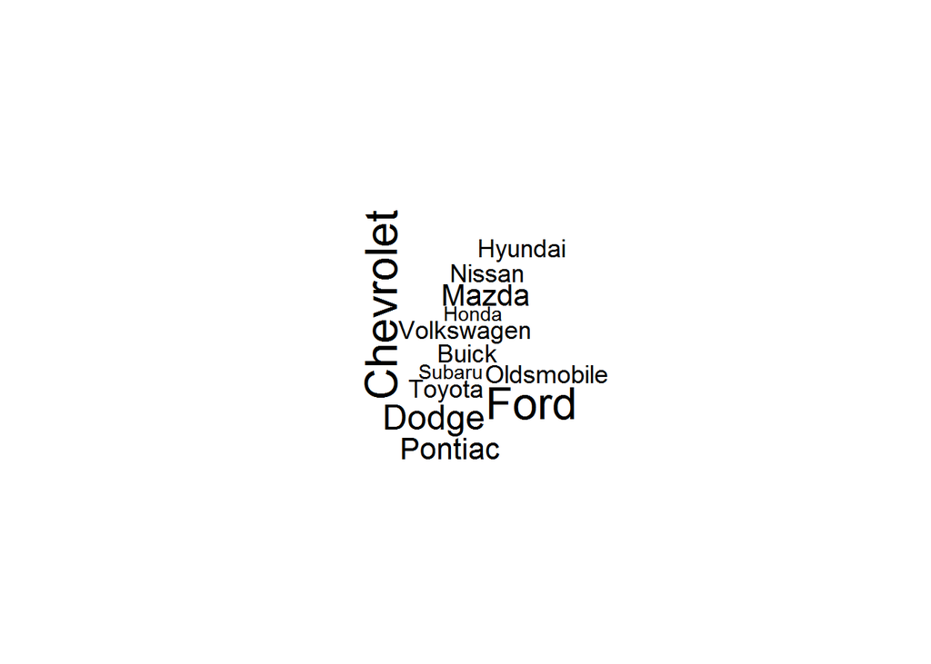

```r
library("wordcloud")
# Create mfr_table of manufacturer frequencies
mfr_table <- table(Cars93$Manufacturer)

# Create the default wordcloud from this table
wordcloud(words = names(mfr_table),
          freq = as.numeric(mfr_table),
          scale = c(2,0.25))
```

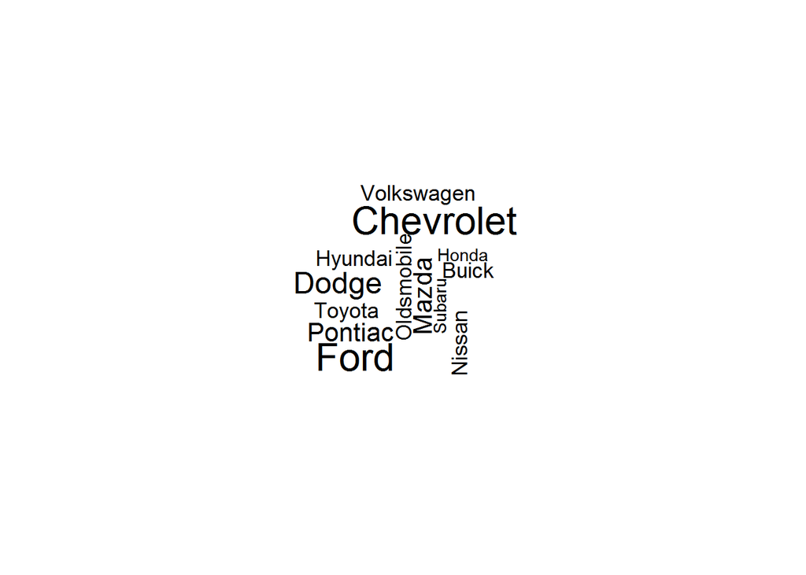

```r
# Change the minimum word frequency
wordcloud(words = names(mfr_table),
          freq = as.numeric(mfr_table),
          scale = c(2, 0.25),
          min.freq = 3)
```

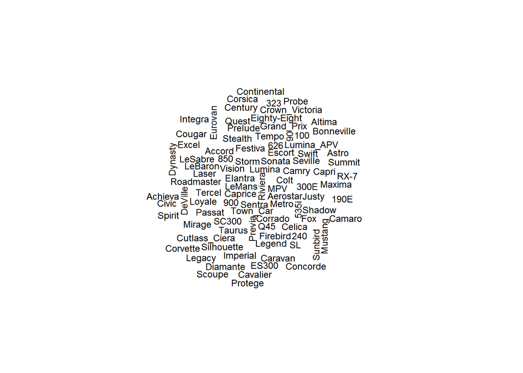

```r
# Create model_table of model frequencies
model_table <- table(Cars93$Model)

# Create the wordcloud of all model names with smaller scaling
wordcloud(words = names(model_table),
          freq = as.numeric(model_table),
          scale = c(0.75, 0.25),
          min.freq = 1)
```

### The Anscombe quartet

In spite of these apparent similarities, the behavior of the four datasets is quite different and this becomes immediately apparent when we plot them.

### INSTRUCTIONS

Use the par() function to set up a two-by-two plot array. Using plot(), create 4 separate plots from the anscombe data frame: y1 vs. x1 y2 vs. x2 y3 vs. x3 y4 vs. x4

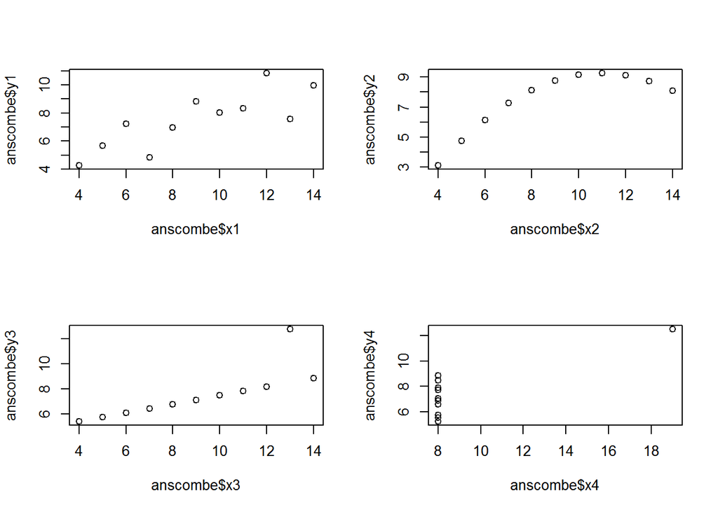

```r
# Set up a two-by-two plot array
par(mfrow = c(2,2))

# Plot y1 vs. x1
plot(anscombe$x1, anscombe$y1)

# Plot y2 vs. x2
plot(anscombe$x2, anscombe$y2)

# Plot y3 vs. x3
plot(anscombe$x3, anscombe$y3)

# Plot y4 vs. x4
plot(anscombe$x4, anscombe$y4)
```

### The utility of common scaling and individual titles

The plots you generated in the previous exercise showed that the four Anscombe quartet datasets have very different appearances, but a careful examination of these plots reveals that they exhibit different ranges of x and y values.

The point of this exercise is to illustrate how much more clearly we can see the differences in these datasets if we plot all of them with the same x and y ranges. This exercise also illustrates the utility of improving the x- and y-axis labels and of adding informative plot titles.

### INSTRUCTIONS

Examine the range of x and y values from the previous four plots to determine a common range that covers the ranges of all four of these plots. Use integer values to keep things simple. Set up a two-by-two plot array using the par() function. Plot the y1 variable against the x1 variable using these common ranges, with x-axis label “x value” and y-axis label “y value”, and use the main argument to add the title “First dataset”. Repeat for the other three Anscombe data pairs, adding the appropriate titles.

[figure not shown]

```r
# Define common x and y limits for the four plots
xmin <- 4
xmax <- 19
ymin <- 3
ymax <- 13

# Set up a two-by-two plot array
par(mfrow = c(2,2))

# Plot y1 vs. x1 with common x and y limits, labels & title
plot(anscombe$x1, anscombe$y1,
     xlim = c(xmin, xmax),
     ylim = c(ymin, ymax),
     xlab = "x value", ylab = "y value",
     main = "First dataset")

# Do the same for the y2 vs. x2 plot
plot(anscombe$x2, anscombe$y2,
     xlim = c(xmin, xmax),
     ylim = c(ymin, ymax),
     xlab = "x value", ylab = "y value",
     main = "Second dataset")

# Do the same for the y3 vs. x3 plot
plot(anscombe$x3, anscombe$y3,
     xlim = c(xmin, xmax),
     ylim = c(ymin, ymax),
     xlab = "x value", ylab = "y value",
     main = "Third dataset")

# Do the same for the y4 vs. x4 plot
plot(anscombe$x4, anscombe$y4,
     xlim = c(xmin, xmax),
     ylim = c(ymin, ymax),
     xlab = "x value", ylab = "y value",
     main = "Fourth dataset")
```

### Using multiple plots to give multiple views of a dataset

As noted in the video, another useful application of multiple plot arrays besides comparison is presenting multiple related views of the same dataset.

This exercise illustrates this idea, giving four views of the same dataset: a plot of the raw data values themselves, a histogram of these data values, a density plot, and a normal QQ-plot.

### INSTRUCTIONS

Note that the MASS and car packages have been pre-loaded, making the geyser data and the truehist() and qqPlot() fuctions available for your use. Use the par() function to set the mfrow parameter for a two-by-two plot array. In the upper left, use the plot() function to show the values of the duration variable from the geyser dataset, using the main argument to specify the plot title as “Raw data”. In the upper right, use the truehist() function to generate a histogram of the duration data, using the main argument to give this plot the title “Histogram”. In the lower left, use the plot() and density() functions to display the density of the duration values, using the main argument to give this plot the title “Density”. In the lower right, use the qqPlot() function from the car package to display a normal QQ-plot of the duration data, using the main argument to give this plot the title “QQ-plot”.

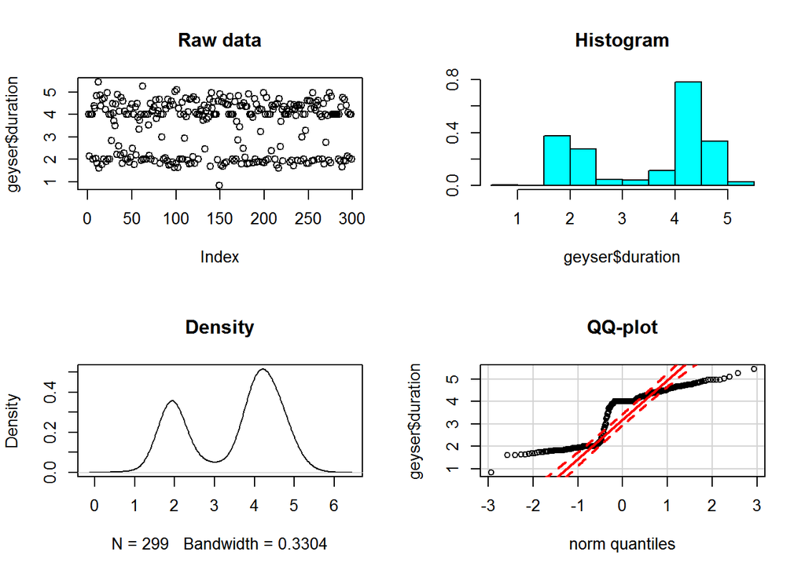

```r
# Set up a two-by-two plot array
par(mfrow = c(2,2))

# Plot the raw duration data
plot(geyser$duration, main = "Raw data")

# Plot the normalized histogram of the duration data
truehist(geyser$duration, main = "Histogram")

# Plot the density of the duration data
plot(density(geyser$duration), main = "Density")

# Construct the normal QQ-plot of the duration data
qqPlot(geyser$duration, main = "QQ-plot")
```

### Constructing and displaying layout matrices

The video illustrated how to set up a layout matrix to be used with the layout() function in creating a plot array. You can think of the layout matrix as the plot pane, where a 0 represents empty space and other numbers represent the plot number, which is determined by the sequence of visualization function calls. For example, a 1 in the layout matrix refers to the visualization that was first called, a 2 refers to the plot of the second visualization call, etc. This exercise asks you to create your own 3 x 2 layout matrix, using the c() function to concatenate numbers into vectors that will form the rows of the matrix.

You will then use the matrix() function to convert these rows into a matrix and apply the layout() function to set up the desired plot array. The convenience function layout.show() can then be used to verify that the plot array has the shape you want.

As reference, feel free to use the slides from the video, which you can access by clicking on the “Slides” tab next to the “R Console” tab. Pay close attention to the example layout matrix and the resulting plot array.

### INSTRUCTIONS

Using the matrix() function, create a matrix called layoutMatrix with three rows and two columns: the first row designates an empty plot to the left and plot 1 to the right. the second row designates plot 2 to the left and an empty plot to the right. the third row designates an empty plot to the left and plot 3 to the right. Use the layout() function to set up the desired plot array. Use the layout.show() function to show the arrangement of all three plots.

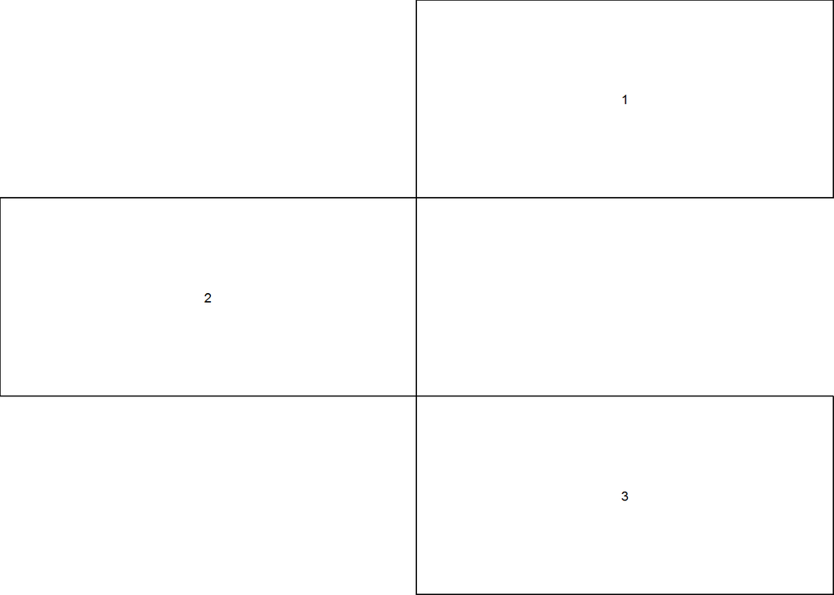

```r
# Use the matrix function to create a matrix with three rows and two columns
layoutMatrix <- matrix(
  c(
    0, 1,
    2, 0,
    0, 3
  ),
  byrow = TRUE,
  nrow = 3
)

# Call the layout() function to set up the plot array
layout(layoutMatrix)

# Show where the three plots will go
layout.show(n=3)
```

### Creating a triangular array of plots

The previous exercise asked you to create a plot array using the layout() function. Recall the layout matrix from the previous exercise:

> layoutMatrix [,1] [,2] [1,] 0 1 [2,] 2 0 [3,] 0 3

This exercise asks you to use this array to give three different views of the whiteside data frame.

The primary motivation for this exercise is that it is not possible to construct a plot array in this format using the mfrow parameter, since the array is not rectangular.

INSTRUCTIONS 100XP INSTRUCTIONS 100XP The layout matrix you set up in the previous is available in your workspace as layoutMatrix. The whiteside data frame is already available in your workspace as well.

Call the layout() function on layoutMatrix to set up the plot array. Construct a vector indexB that points to only those records with the Insul value “Before” and a vector indexA that points to only those records with the Insul value “After”. Plot the Gas versus Temp values from the indexB data in the upper right plot in your array, using the y-axis limits c(0, 8). Give this plot the title “Before data only”. Plot the Gas versus Temp values from the complete dataset in the center left plot, using the same y-axis limits as the first plot. Give this plot the title “Complete dataset”. Plot the Gas versus Temp values from the indexA data in the lower right plot, again using the same y-axis limits. Give this plot the title “After data only”.

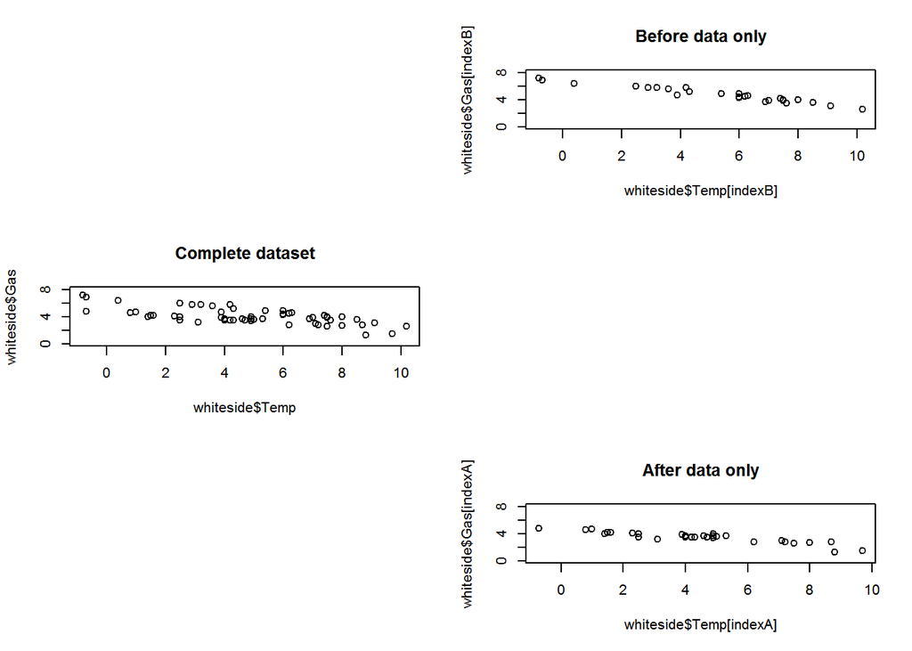

```r
# Set up the plot array
layout(layoutMatrix)

# Construct vectors indexB and indexA
indexB <- which(whiteside$Insul == "Before")
indexA <- which(whiteside$Insul == "After")

# Create plot 1 and add title
plot(whiteside$Temp[indexB], whiteside$Gas[indexB],
     ylim = c(0,8))
title("Before data only")

# Create plot 2 and add title
plot(whiteside$Temp, whiteside$Gas,
     ylim = c(0,8))
title("Complete dataset")

# Create plot 3 and add title
plot(whiteside$Temp[indexA], whiteside$Gas[indexA],
     ylim = c(0,8))
title("After data only")
```

### Creating arrays with different sized plots

Besides creating non-rectangular arrays, the layout() function can be used to create plot arrays with different sized component plots – something else that is not possible by setting the par() function’s mfrow parameter.

This exercise illustrates the point, asking you to create a standard scatterplot of the zn versus rad variables from the Boston data frame as a smaller plot in the upper left, with a larger sunflower plot of the same data in the lower right.

INSTRUCTIONS

The Boston data frame in the MASS package is already available in your workspace.

Using the c() function: Create the three-element vector row1 with values (1, 0, 0). Create the three-element vector row2 with values (0, 2, 2). Combine the first vector with two copies of the second vector into layoutVector, a vector of length 9. Using the matrix() function, convert layoutVector into the 3-by-3 matrix layoutMatrix whose first row is row1 and whose second and third rows are row2. Use the layout() function with layoutMatrix to configure a two-element plot array. In the first (smaller) plot, create a standard scatterplot of the zn variable versus the rad variable from the Boston data frame. In the second (larger) plot, create a sunflower plot using the sunflowerplot() function and the same variables.

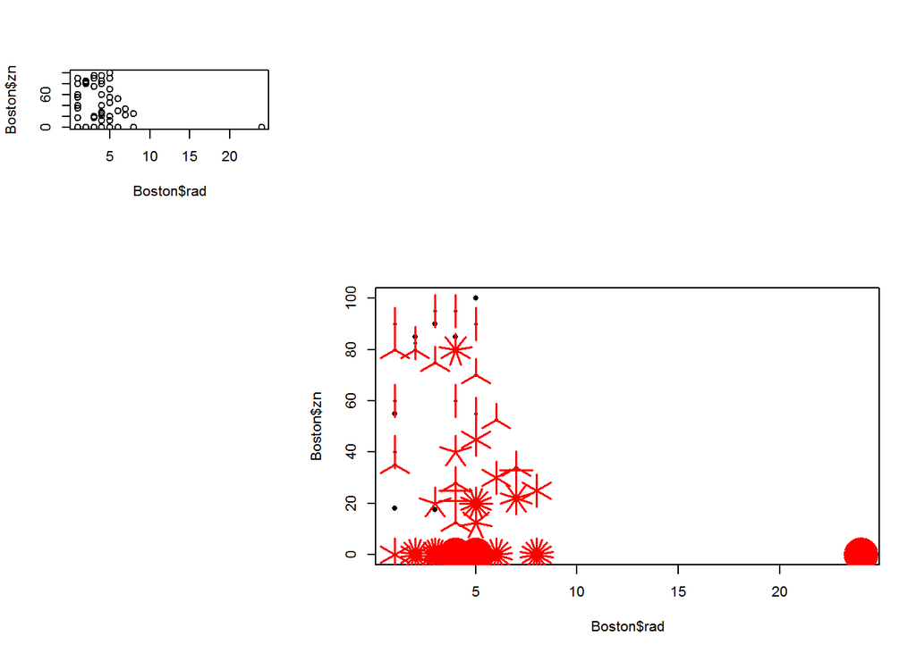

```r
# Create row1, row2, and layoutVector
row1 <- c(1,0,0)
row2 <- c(0,2,2)
layoutVector <- c(row1, row2, row2)

# Convert layoutVector into layoutMatrix
layoutMatrix <- matrix(layoutVector, byrow = TRUE, nrow = 3)

# Set up the plot array
layout(layoutMatrix)

# Plot scatterplot
plot(Boston$rad, Boston$zn)

# Plot sunflower plot
sunflowerplot(Boston$rad, Boston$zn)
```

## Advanced plot customization and beyond

This final chapter introduces a number of important topics, including the use of numerical plot details returned invisibly by functions like barplot() to enhance our plots, and saving plots to external files so they don’t vanish when we end our current R session. This chapter also offers some guidelines for using color effectively in data visualizations, and it concludes with a brief introduction to the other three graphics systems in R.

### Some plot functions also return useful information

As shown in the video, calling the barplot() function has the side effect of creating the plot we want, but it also returns a numerical vector with the center positions of each bar in the plot. This value is returned invisibly so we don’t normally see it, but we can capture it with an assignment statement.

These return values can be especially useful when we want to overlay text on the bars of a horizontal barplot. Then, we capture the return values and use them as the y parameter in a subsequent call to the text() function, allowing us to place the text at whatever x position we want but overlaid in the middle of each horizontal bar. This exercise asks you to construct a horizontal barplot that exploits these possibilities.

Feel free to reference a similar example in the slides by clicking on the “Slides” tab next to the “R Console” tab.

INSTRUCTIONS

The Cars93 data frame from the MASS package is already available in your workspace.

Use the table() function to generate the object tbl summarizing the number of records listing each value of the Cylinders variable from the Cars93 data frame. Use the barplot() function with the horiz argument set to TRUE to construct a horizontal barplot of this record summary, specifying the color of the bars to be “transparent” and returning the vector mids giving the vertical positions of the centers of each bar in the plot. Specify the names.arg argument as “” to suppress the y-axis legend on this plot. Use the text() function to label the Cylinders value for each bar in the barplot at the horizontal position 20. The names() function may prove useful here. Use the text() function to list the counts for each cylinders value at the horizontal position 35. Here, the as.numeric() function may prove useful.

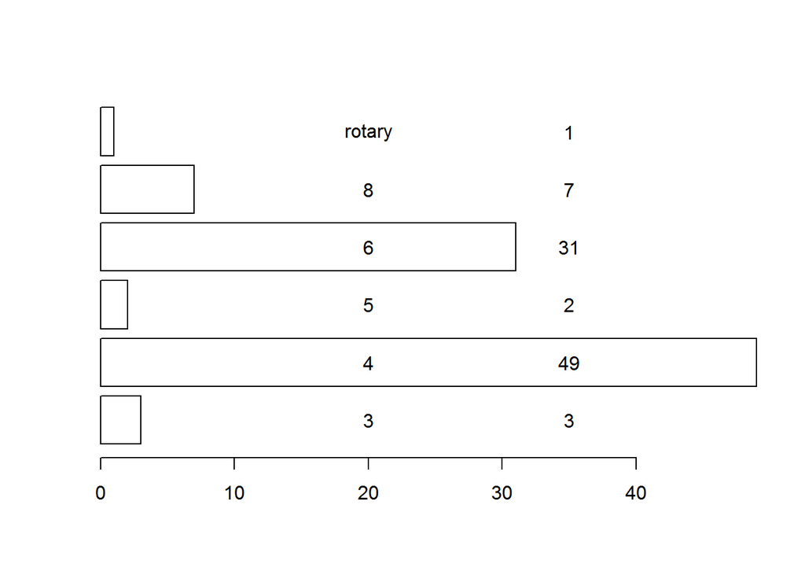

```r
# Create a table of Cylinders frequencies
tbl <- table(Cars93$Cylinders)

# Generate a horizontal barplot of these frequencies
mids <- barplot(tbl, horiz = TRUE,
                col = "transparent",
                names.arg = "")

# Add names labels with text()
text(20, mids, names(tbl))

# Add count labels with text()
text(35, mids, as.numeric(tbl))
```

### Using the symbols() function to display relations between more than two variables

The scatterplot allows us to see how one numerical variable changes with the values of a second numerical variable. The symbols() function allows us to extend scatterplots to show the influence of other variables.

This function is called with the variables x and y that define a scatterplot, along with another argument that specifies one of several possible shapes. Here, you are asked to use the circles argument to create a bubbleplot where each data point is represented by a circle whose radius depends on the third variable specified by the value of this argument.

INSTRUCTIONS

The Cars93 data frame from the MASS package is already available in your workspace.

Use the symbols() function with its default settings and the appropriate arguments to create a bubble plot of MPG.city versus Horsepower from the Cars93 data frame, with the bubble area by the Price variable. Note that this means the bubble radius should be proportional to the square root of Price. Re-create the first plot, but with the optional argument inches set to 0.1.

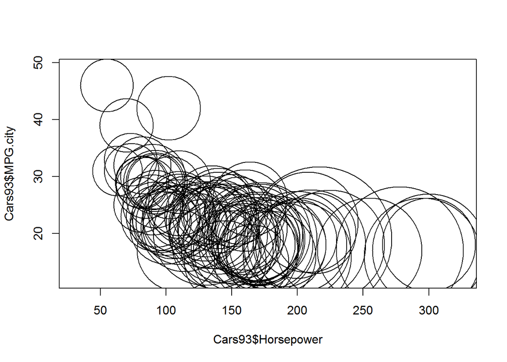

```r
# Call symbols() to create the default bubbleplot
symbols(Cars93$Horsepower, Cars93$MPG.city,
        circles = sqrt(Cars93$Price))
```

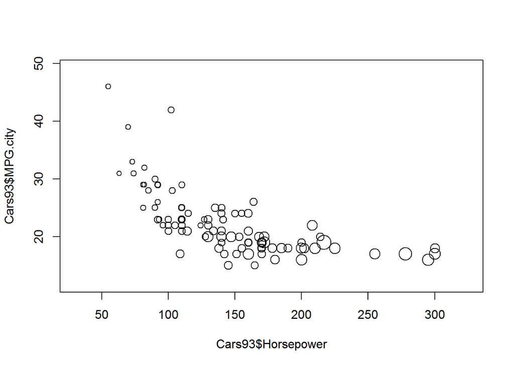

```r
# Repeat, with the inches argument specified
symbols(Cars93$Horsepower, Cars93$MPG.city,
        circles = sqrt(Cars93$Price),
        inches = 0.1)
```

### Saving plot results as files

In an interactive R session, we typically generate a collection of different plots, often using the results to help us decide how to proceed with our analysis. This is particularly true in the early phases of an exploratory data analysis, but once we have generated a plot we want to share with others, it is important to save it in an external file.

R provides support for saving graphical results in several different external file formats, including jpeg, png, tiff, or pdf files. In addition, we can incorporate graphical results into external documents, using tools like the Sweave() function or the knitr package. One particularly convenient way of doing this is to create an R Markdown document, an approach that forms the basis for another DataCamp course.

Because png files can be easily shared and viewed as e-mail attachments and incorporated into many slide preparation packages (e.g. Microsoft Powerpoint), this exercise asks you to create a plot and save it as a png file. The basis for this process is the png() function, which specifies the name of the png file to be generated and sets up a special environment that captures all graphical output until we exit this environment with the dev.off() command.

### INSTRUCTIONS

Use the png() function to direct all subsequent plot results to the external file bubbleplot.png. Run the code to re-create the second bubble plot from the previous exercise. Exit the png() environment to return graphics control to your session by calling dev.off(). Use the list.files() code provided to verify that bubbleplot.png was created. To do this, you need to specify “png” as the value to the pattern argument to list.files().

```r
# Call png() with the name of the file we want to create
png("bubbleplot.png")

# Re-create the plot from the last exercise
symbols(Cars93$Horsepower, Cars93$MPG.city,
        circles = sqrt(Cars93$Price),
        inches = 0.1)

# Save our file and return to our interactive session
dev.off()
```

```r
# Verify that we have created the file
list.files(pattern = "png")
```

```
## [1] "bubbleplot.png"
```

### Iliinsky and Steele’s 12 recommended colors

This exercise asks you to create a horizontal barplot that shows Iliinsky and Steele’s set of recommended 12 colors, in descending order of desirability from the top of the plot to the bottom. Also, the first six “more preferred” colors are displayed with longer bars to visually emphasize their preferred status over the other six.

Code is provided to create the character vector IScolors with the names of the 12 colors recommended by Iliinsky and Steele, in their recommended order. We’ve also created the numeric vector barWidths containing the value 2 for the first six Iliinsky and Steele colors and the value 1 for the next six.

In this exercise, you’ll use the barplot() function to create the horizontal barplot shown in the preceeding figure, with the color names to the left of the bars and each bar drawn in the indicated color.

INSTRUCTIONS

Notice how the barWidths vector of length 12 contains the length of each bar shown. The 6 longer bars have a value of 2. The 6 shorter ones have a value of 1. Recreate the horizontal barplot you see on the right, using the horiz, col, axes, names.arg, and las arguments to barplot(). Note that since the horizontal barplot is constructed from the bottom up, it is necessary to reverse the IScolors and barWidths vectors in the barplot() function call, using the rev() function.

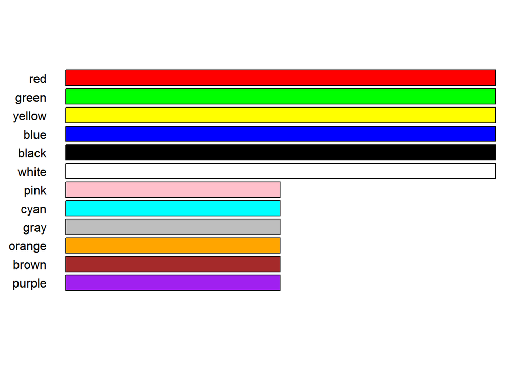

```r
# Iliinsky and Steele color name vector
IScolors <- c("red", "green", "yellow", "blue",
              "black", "white", "pink", "cyan",
              "gray", "orange", "brown", "purple")

# Create the data for the barplot
barWidths <- c(rep(2, 6), rep(1, 6))

# Recreate the horizontal barplot with colored bars
barplot(rev(barWidths), horiz = TRUE, col = rev(IScolors), axes = FALSE,
        names.arg = rev(IScolors), las = 1)
```

### Using color to enhance a bubbleplot

In a previous exercise, you saw how the symbols() function could be used to generate a bubbleplot showing the relationship between three variables (specifically, Horsepower, MPG.city, and Price from the Cars93 data frame). There, the basic format was a scatterplot of MPG.city versus Horsepower, with points represented as bubbles, sized by Price.

Here, you are asked to create a variation on this plot, using the factor variable Cylinders to determine both the size and the color of the bubbles. To do this, note that as.numeric(Cars93$Cylinders) generates a sequence of numerical values from 1 to 6 that specify the six unique levels of the Cylinders factor.

The point of this exercise is to show that, in cases where color is an option, the clarity of this bubbleplot can be improved substantially through the use of color in addition to symbol size. Since the Cylinders variable exhibits six unique values, six colors are required to make this enhancement, so the top six colors recommended by Iliinsky and Steele are used here.

### INSTRUCTIONS

The Cars93 data frame in the MASS package is available in your workspace, and the vector IScolors of color names is created in the code included at the beginning of the exercise.

Create the vector cylinderLevels giving numerical labels to the unique values of the Cylinders variable. Using the symbols() function, recreate the bubbleplot shown on the right of MPG.city vs. Horsepower with the bubbles sized by the cylinderLevels variable. Specify a maximum circle radius of 0.2 inches. Use the bg parameter to color each bubble according to the numerical level of the Cylinders factor variable (i.e., the cylinderLevels values), using the first six recommended colors from Iliinsky and Steele (e.g. the first Cylinder level should be colored “red”, the second level colored “green”, etc.)

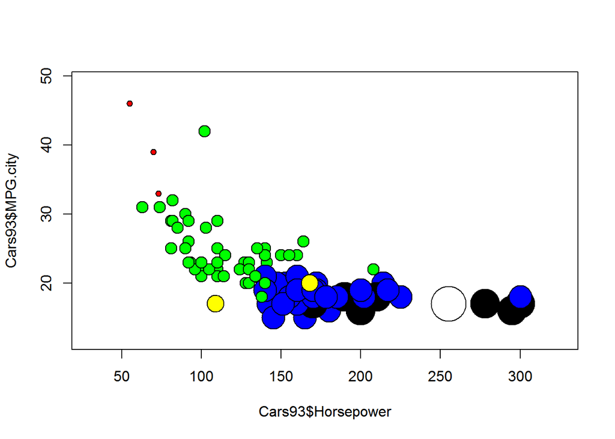

```r
# Iliinsky and Steele color name vector
IScolors <- c("red", "green", "yellow", "blue",
              "black", "white", "pink", "cyan",
              "gray", "orange", "brown", "purple")

# Create the `cylinderLevel` variable
cylinderLevels <- as.numeric(Cars93$Cylinders)

# Create the colored bubbleplot
symbols(Cars93$Horsepower, Cars93$MPG.city,
        circles = cylinderLevels, inches = .2,
        bg = IScolors[cylinderLevels])
```

### Using color to enhance stacked barplots

The most common barplot consists of a collection of vertical bars, each representing some characteristic of one of a finite number of datasets or data subsets. Several previous exercises have illustrated the utility of the somewhat less common horizontal barplot, useful in part because it allows text to be displayed horizontally across the bars, as illustrated in Exercise 1.

Another useful variant of the standard bar plot is the stacked bar plot, where each bar in the plot is partitioned into segments characterizing portions of the data characterized by the bar. Stacked bar plots can also be generated using the barplot() function. Here, each bar is specified by a matrix whose columns specify the heights of the segments in each bar.

By default, the barplot() function generates stacked bar plots using different shades of gray for the different segments of each bar in the plot. The point of this exercise is to show that, if we can use it, color can be a more effective alternative.

### INSTRUCTIONS

The character vector IScolors from the previous exercises is still available in your workspace.

Create the table tbl giving the record counts for each Cylinders value at each Origin value (this table should have 6 rows and 2 columns). Using the barplot() function, create a stacked barplot that summarizes this information using shades of gray. Recreate this first plot, but using the first six Iliinsky and Steele colors for the six Cylinders levels.

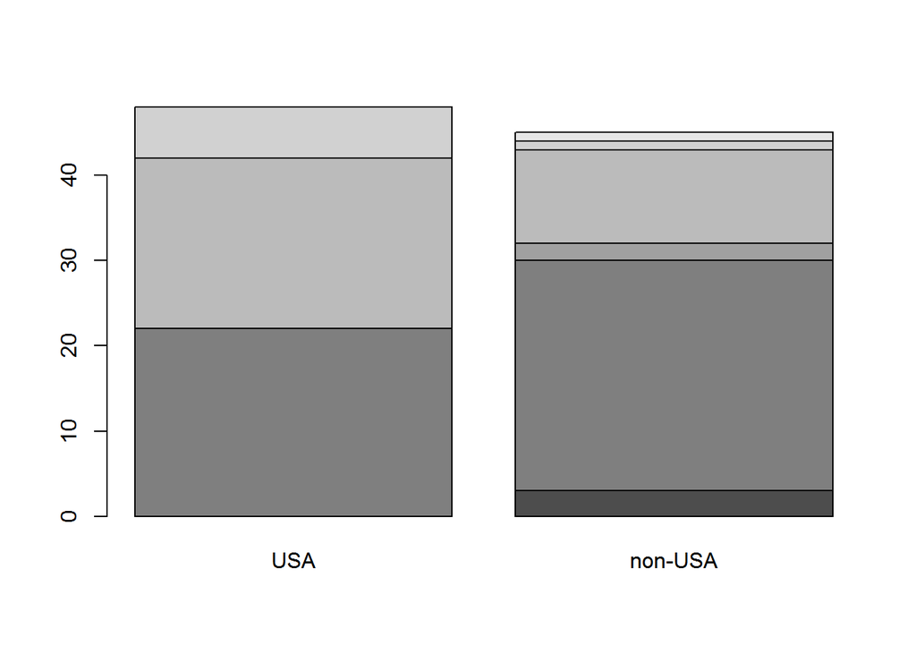

```r
# Create a table of Cylinders by Origin
tbl <- table(Cars93$Cylinders, Cars93$Origin)

# Create the default stacked barplot
barplot(tbl)
```

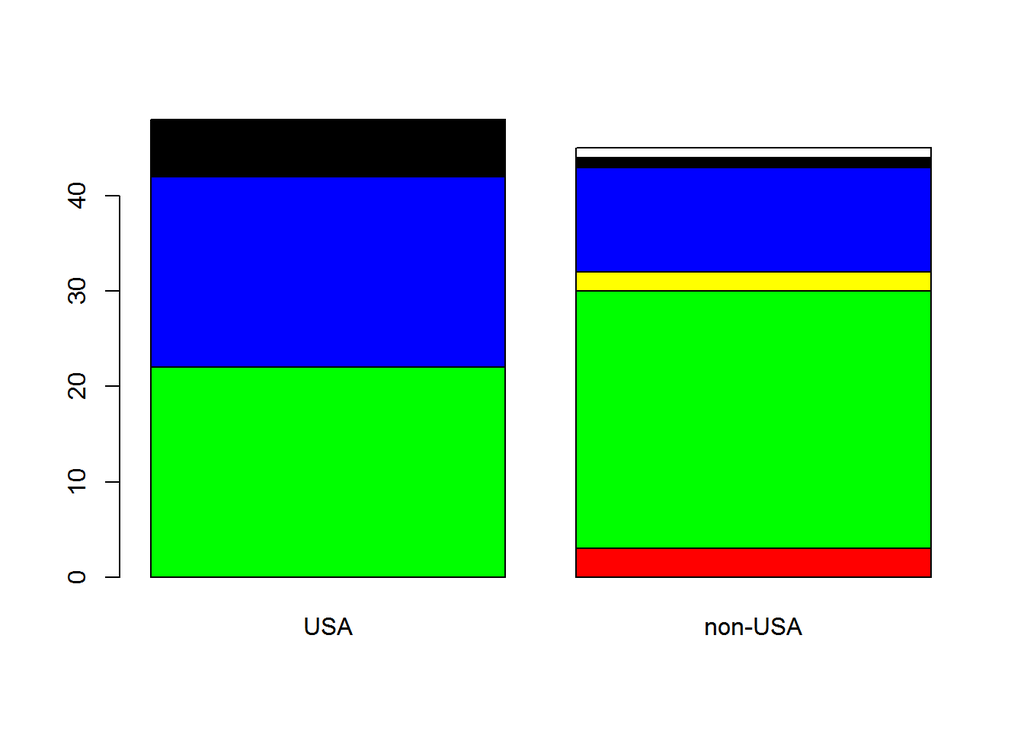

```r
# Enhance this plot with color
barplot(tbl, col = IScolors)
```

### The tabplot package and grid graphics

The tabplot package allows you to tap into the power of grid graphics without explicit knowledge of how the system works under the hood. The main function in tabplot is tableplot(), developed to visualize data distributions and relationships between variables in large datasets.

Specifically, the tableplot() function constructs a set of side-by-side horizontal barplots, one for each variable. This function works best when viewing up to about 10 variables at a time, for datasets with arbitrarily many records. In this exercise, you are asked to apply this function to a dataset with just under 68,000 records and 11 variables.

The tableplot() function is called with a data frame and, if no optional arguments are specified, it selects the first data column as the reference variable. This variable can be of any type, but the display is easiest to explain when it’s numeric, as in the example considered here.

For further details, refer to the vignette Visualization of large datasets with tabplot that accompanies the help files for the tabplot package.

INSTRUCTIONS

Load the insuranceData package. Use the data() function to load the dataCar data frame. Load the tabplot package the normal way, but surround your call to library() with the suppressPackageStartupMessages() function to avoid a bunch of unncessary output from printing to the console. Apply the tableplot() function to the dataCar data frame.

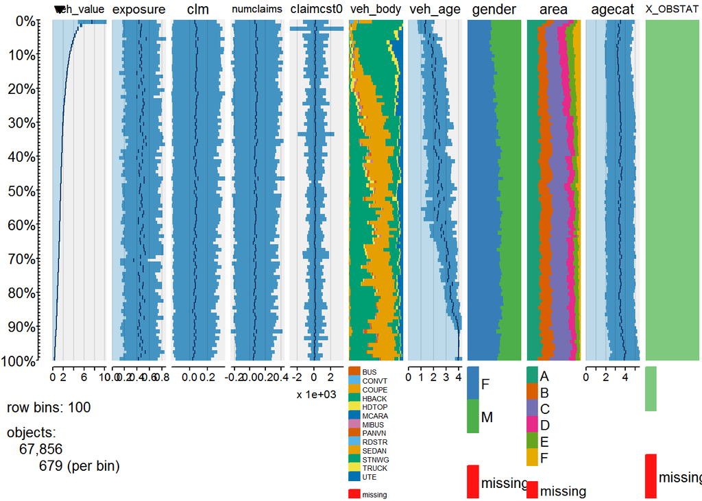

```r
library("gridExtra")
# Load the insuranceData package
library("insuranceData")

# Use the data() function to load the dataCar data frame
data(dataCar)

# Load the tabplot package
suppressPackageStartupMessages(library("tabplot"))

# Generate the default tableplot() display
tableplot(dataCar)
```

### A lattice graphics example

Another package built on grid graphics is lattice, but unlike tabplot, lattice is a general-purpose graphics package that provides alternative implementations of many of the plotting functions available in base graphics. Specific examples include scatterplots with the xyplot() function, bar charts with the barchart() function, and boxplots with the bwplot() function.

One important difference between lattice graphics and base graphics is that similar functions available in both graphics systems often produce very different results when applied to the same data. As a specific example, the bwplot() function creates horizontal boxplots, while the default result of the boxplot() is a vertical boxplot display.

Another more important difference between lattice and base graphics is that lattice graphics supports conditional plots that show the separate relationships between variables within different groups. This capability is illustrated in this exercise, where you are asked to construct a plot showing the relationship between the variables calories and sugars from the UScereal data frame, conditional on the value of the shelf variable.

### INSTRUCTIONS

Load the lattice package to make the function xyplot() available. Using the conditional formula format “y ~ x | z” (scatterplot of y vs. x, conditioned on z), construct a conditional scatterplot of calories vs. sugars conditional on shelf from the UScereal data frame in the MASS package. Make sure to convert shelf to a factor.

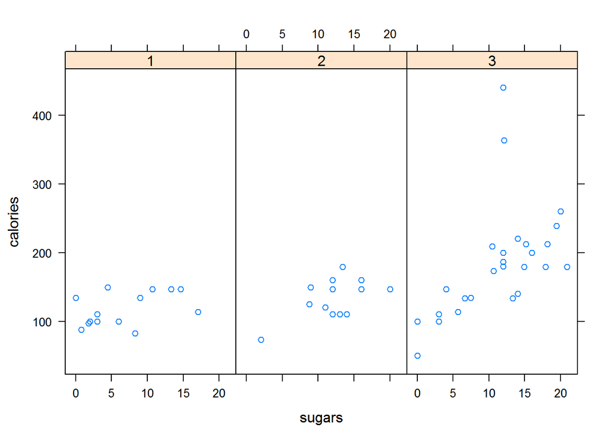

```r
# Load the lattice package
library("lattice")

# Use xyplot() to construct the conditional scatterplot
xyplot(calories ~ sugars | as.factor(shelf), data = UScereal)
```

### A ggplot2 graphics example

This final exercise provides an introduction to the ggplot2 graphics package. Like the lattice package, the ggplot2 package is also based on grid graphics and it also represents a general purpose graphics package.

The unique feature of the ggplot2 package is that it is based on the grammar of graphics, a systematic approach to building and modifying graphical displays, starting with a basic graphics element and refining it through the addition of successive modifiers.

This exercise provides a simple illustration of the approach. Specifically, you are asked to use ggplot2 to, first, create a simple scatterplot of MPG.city versus Horsepower from the Cars93 data frame. Next, you are asked to add a simple modifier that adds color based on the value of the Cylinders variable. Finally, you are asked to convert this result into a colored bubble plot, with both bubble sizes and colors determined by the Cylinders variable.

The primary purpose of this exercise is to give you a flavor of the ggplot2 package. DataCamp offers several courses dedicated to using this popular graphics package to generate high-quality data visualizations.

INSTRUCTIONS

The character vector IScolors from the previous exercises is still available in your workspace.

Load the ggplot2 package. Create basePlot as the ggplot object based on the Cars93 data frame from the MASS package and the scatterplot aesthetic with x as the Horsepower variable and y as the MPG.city variable. When passing the variable names to x and y, they should be unquoted (e.g. x = var_name). (Note that this definition does not render the scatterplot.) Make a simple rendering of basePlot with the geom_point() function. Make a second rendering using the colour parameter of geom_point() to specify the first six Iliinsky-Steele colors for the six Cylinders levels. Make a third rendering with the same coloring as the second one, but with the point sizes corresponding to the levels of the Cylinders factor variable.

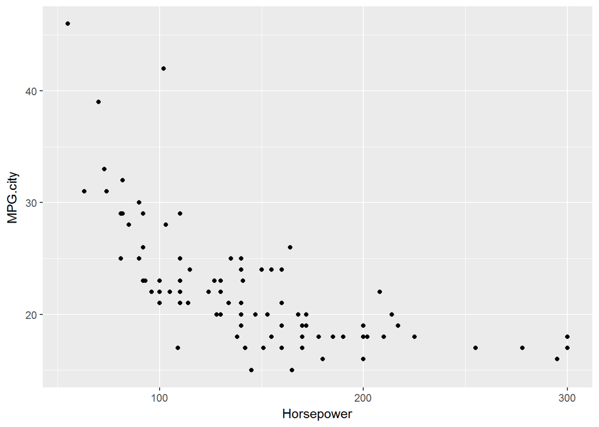

```r
# Load the ggplot2 package
library(ggplot2)

# Create the basic plot (not displayed): basePlot
basePlot <- ggplot(Cars93, aes(x = Horsepower, y = MPG.city))

# Display the basic scatterplot
basePlot +
  geom_point()
```

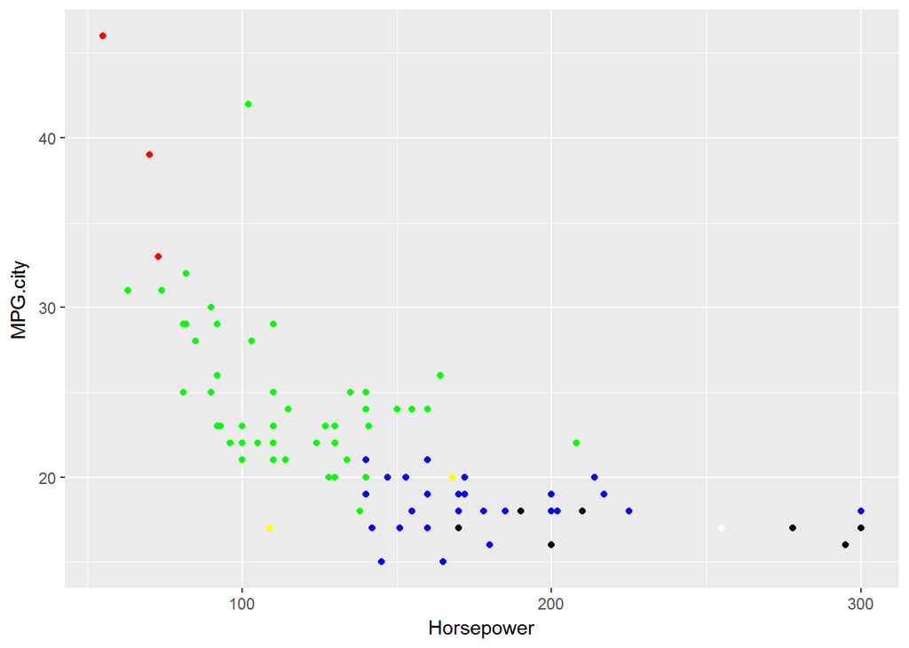

```r
# Color the points by Cylinders value
basePlot +
  geom_point(colour = IScolors[Cars93$Cylinders])
```

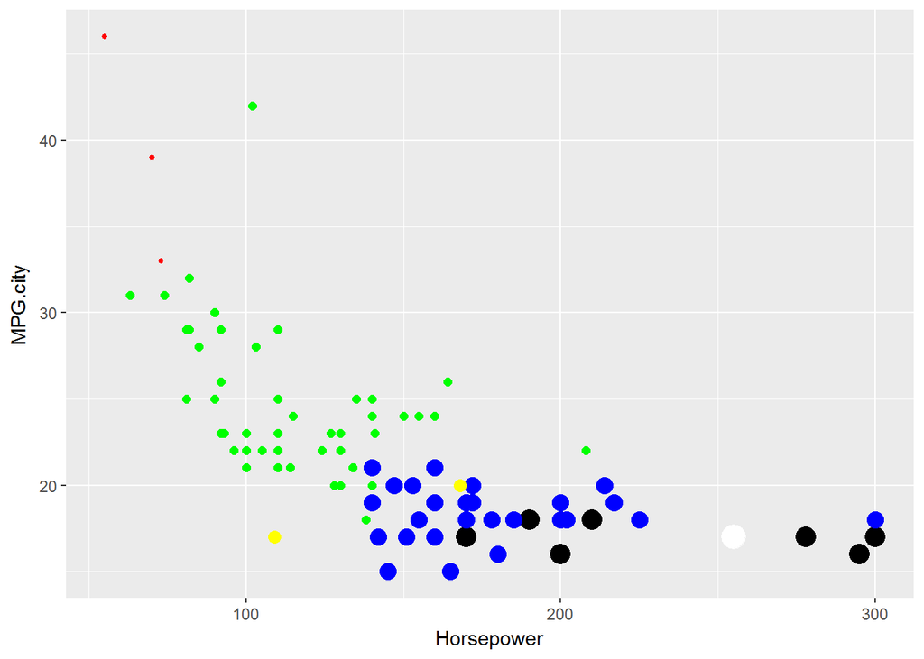

```r
# Make the point sizes also vary with Cylinders value
basePlot +
  geom_point(colour = IScolors[Cars93$Cylinders],
             size = as.numeric(Cars93$Cylinders))
```